# Analiza rozkładu oraz częstości występowania raka piersi w Polsce

Alicja Gosiewska, Mateusz Jastrząb, Gabriela Jaworska, Izabela Lis

18 maja 2016

## Pytania badawcze

Nasza analiza ma na celu odpowiedzenie na następujące pytania.

#### 1. Jak wygląda rozkład zachorowań na raka piersi w Polsce? Czy można wyodrębnić regiony o większym ryzyku zachorowania?

Na to pytanie odpowiemy we wstępnej analizie danych zilustrowanych na mapie Polski. W pierwszej części przeanalizujemy podział na województwa, a następnie na powiaty.

#### 2. Czy osoby mieszkające w dużych miastach lub w ich okolicach częściej wykonują badania?

W celu znalezienia odpowiedzi na to pytanie przeanalizujemy procent wykrywalności raka w pierwszych stadiach choroby w podziale na dwie grupy: osoby mieszkające w miastach na prawach powiatu oraz osoby miekszające w pozostałych powiatach.

#### 3. Który przedział wiekowy charakteryzuje się największym ryzykiem zachorowania na raka piersi?

Aby dowiedzieć się dla jakiego przedziału wiekowego ryzyko zachorowania jest największe, przeanalizujemy mapy ciepła uwzględniające przedział wiekowy.

Aby nasze dane były miarodajne, znormalizujemy je za pomocą danych pochodząch ze strony GUS, dotyczących ludności w poszczególnych powiatach.

Ponieważ nasze dane pochodzą z lat 2010-2012, brakuje w nich miasta Wałbrzych, które obecnie jest już na prawach powiatu, dlatego musieliśmy zmodyfikować mapę, dołączając miasto Wałbrzych do powiatu wałbrzyskiego.

## Analiza częstości występowania raka piersi w różnych rejonach Polski

Na początek przyjrzyjmy się mapie Polski w podziale na województwa. Zaznaczyliśmy na niej częstość zachorowań na raka w poszczególnych województwach.

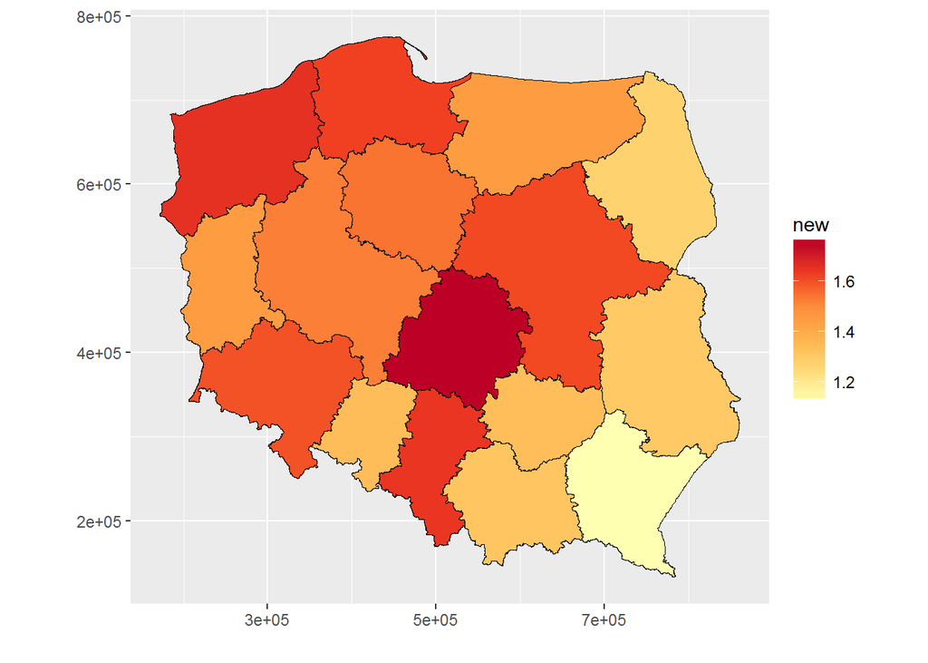

Aby sprawdzić, czy istnieje jakaś tendencja dotycząca powiatów, zobaczmy mapę w podziale na powiaty:

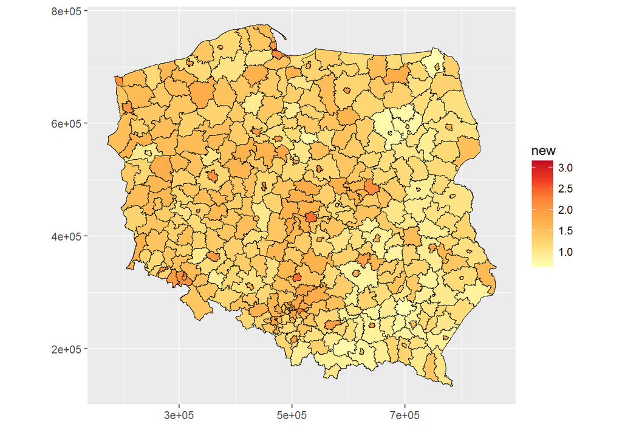

Na tej mapie widać wyraźniej niż na poprzedniej, że na wschodzie Polski jest mniejsze ryzyko zachorowania na raka piersi, niż na zachodzie. Na powyższej mapie widać też inną interesującą zależność: mniejsze obszary(miasta na prawach powiatu) są z reguły oznaczone kolorem ciemniejszym. Może to oznaczać, że liczba zachorowań na raka piersi jest większa w dużych miastach oraz w ich okolicach, niż w rejonach oddalonych od dużych aglomeracji. Ta obserwacja skłoniła nas do dalszej analizy dwóch podzbiorów: miasta (wszystkie miasta w Polsce na prawach powiatu) oraz wsie(wszystkie pozostałe powiaty).

Zobaczmy jak wygląda rozkład zachorowań dla tych dwóch zbiorów:

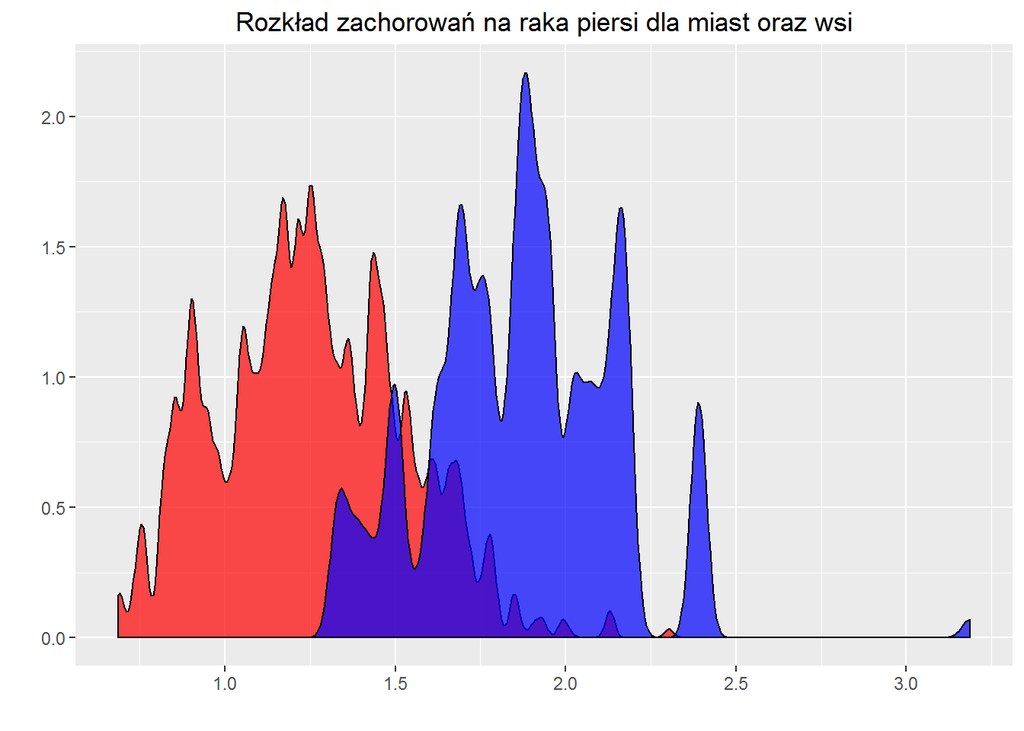

Na wykresie wyraźnie widać, że rozkład zachorowań dla obszarów miejskich jest przesunięty w prawo, co potwierdziło naszą hipotezę o większym ryzyku zachorowania w tych obszarach.

Zobaczmy jak kształtuje się rozkład wykrywalności raka w powyższych podzbiorach w podziale na poszczególne stadia:

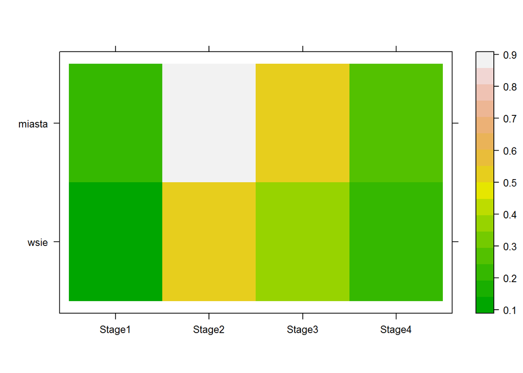

Widać, że w każdym stadium wykrywalność jest wyższa dla miast. W celu odpowiedzenia na pytanie, czy w większych miastach ludzie częściej się badają, zobaczmy jaki jest procent wykrywalności badanego nowotworu w poszczególnych stadiach:

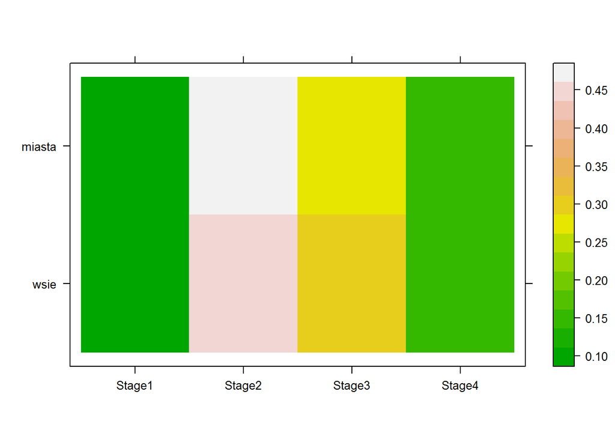

Na mapie ciepła widać, że zarówno w dużych miastach jak i obszarach leżących z dala od nich, rozkład procentowy przedstawia się podobnie. Największa wykrywalność jest w stadiach 2 oraz 3. Wynika z tego, że zarówno osoby z dużych miast jak i z tych mniejszych z podobną częstotliwością chodzą na badania raka piersi.

## Analiza rozkładu zachorowań w różnych przedziałach wiekowych

Poniższa analiza pozwoli nam odpowiedzieć na ostatnie pytanie: Który przedział wiekowy charakteryzuje się największym ryzykiem zachorowania na raka piersi? Do narysowania poniższego wykresu użyliśmy wartości znormalizowanych.

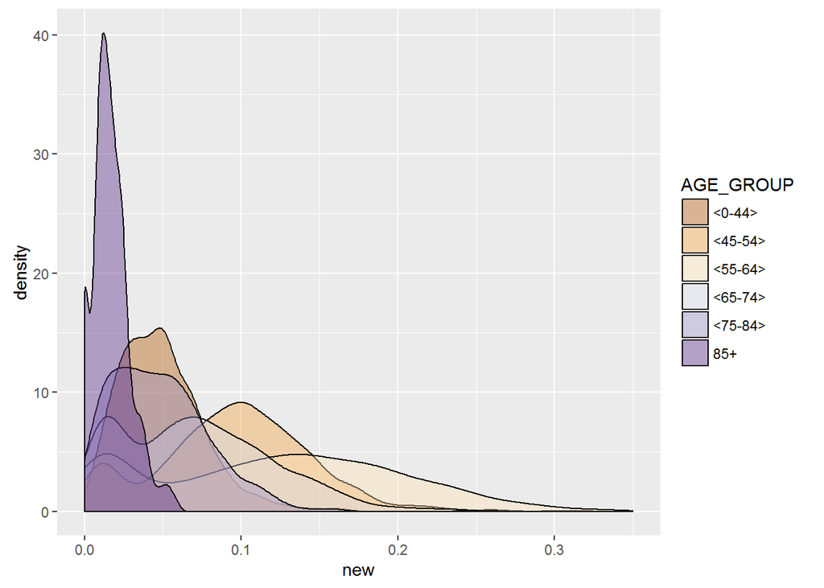

Powyższy wykres sugeruje nam, że największe ryzyko zachorowania na raka piersi występuje w przedziale wiekowym 55-64 lata. Zdecydowanie wyróżnia się również przedział 85+. Dla tego przedziału ryzyko zachorowania jest najmniejsze. Spróbujmy jednak zwizualizować te dane w inny sposób.

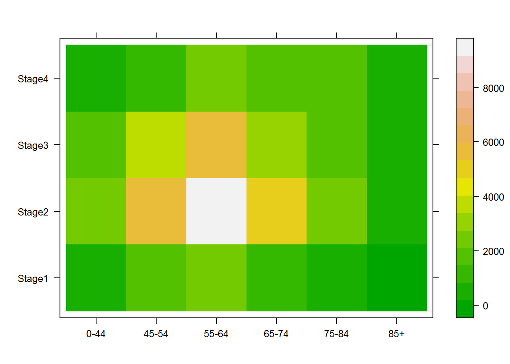

Stworzyliśmy mapę ciepła, która pokazuje, że rzeczywiście największe ryzyko występuje w przedziale wiekowym 55-64. Można na niej dodatkowo zauważyć, że najczęściej wykrywany jest nowotwór znajdujący się w drugim i trzecim stadium.

Powyższa analiza pozwoliła nam odpowiedzieć na postawione na początku pytania:

#### 1. Jak wygląda rozkład zachorowań na raka piersi w Polsce? Czy można wyodrębnić regiony o większym ryzyku zachorowania?

Analiza dwóch map w podziale na województwa oraz powiaty pozwoliła nam stwierdzić, że powiaty leżące we wschodniej części Polski charakteryzują się nieznacznie mniejszym ryzykiem niż te leżące na zachodzie. Ciekawą obserwacją jest fakt, że w miastach na prawach powiatu ryzyko wykrycia raka piersi jest wyższe niż w pozostałych powiatach.

#### 2. Czy osoby mieszkające w dużych miastach lub w ich okolicach częściej wykonują badania?

Nasza analiza pozwoliła odpowiedź przecząco na to pytanie. Rozkład procentowy wykrywalości raka w poszczególnych stadiach jest zbliżony w obydwu grupach, co oznacza, że rak nie jest wykrywany częściej w pierwszym stadium w żadnej z tych grup.

#### 3. Który przedział wiekowy charakteryzuje się największym ryzykiem zachorowania na raka piersi?

Największym ryzykiem charakteryzuje się przedział 55-64 lata. Przedziały o wysokim ryzyku to przedziały sąsiednie: 45-54 oraz 65-74 lata. Najczęśniej nowotwór wykrywany jest w drugim oraz trzecim stadium.

## Załączniki

W załącznikach załączamy mapkę na której przedstawiliśmy procentowy rozkład wykrywalności raka piersi w poszczególnych województwach.

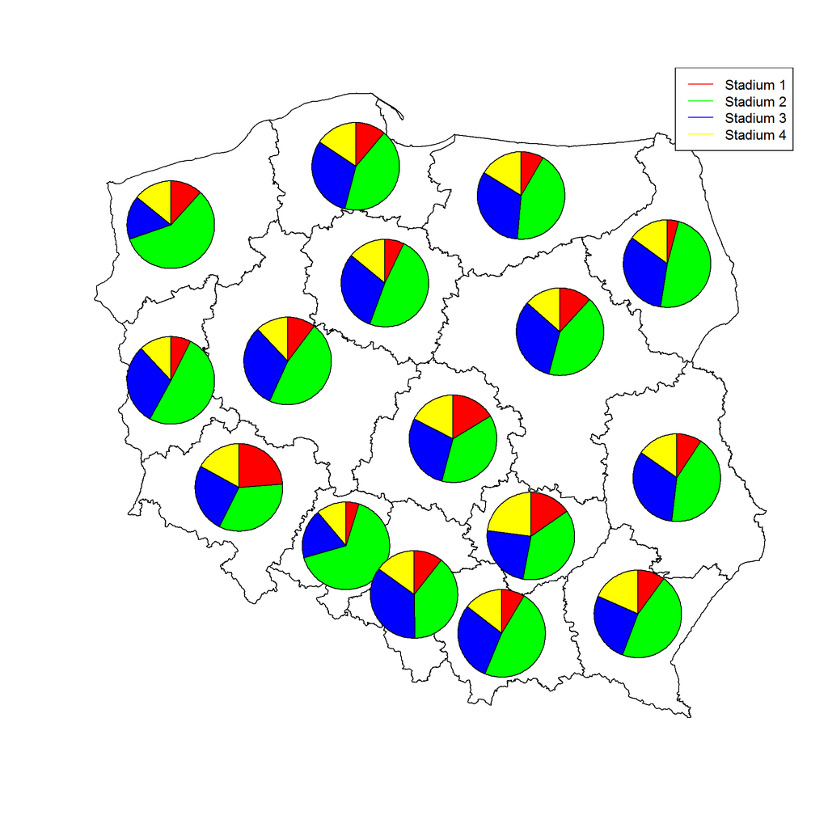